# Stat 184 Final Project

## Front Matter

```r
# clean up workspace environment
rm(list = ls())
# all packages used for the assignment
library(mosaic)
library(tidyverse)
library(DataComputing)
library(mosaicData)
library(ggplot2)
```

### Guiding Question

Are higher salaries associated with better performance for NFL quarterbacks?

### Become Acquainted with Data Source

This is a data source from Kaggle, containing 5,523 cases of NFL player salary data. This was published by “Dr. Hax” and was most recently updated about 10 months ago (around June of 2019). This data is important for the business side of the NFL. I plan mainly to use the average annual salary variable, but I could also use some of the other variables such as the total salary, total guaranteed salary, and fully guaranteed salary variables.

```r
NFL_Salaries <- read.csv("~/R/Stat184FinalProject/Stat 184 Final Project/KaggleFootballSalaries.csv", header = TRUE)
head(NFL_Salaries)
```

|  | position | player | team | age | total_value | avg_year | total_guaranteed | fully_guaranteed | free_agency |
| --- | --- | --- | --- | --- | --- | --- | --- | --- | --- |
| 1 | right-tackle | Trent Brown | Raiders | 26 | 66000000 | 16500000 | 36250000 | 36250000 | 2023 UFA |
| 2 | right-tackle | Ja’Wuan James | Broncos | 27 | 51000000 | 12750000 | 32000000 | 27000000 | 2023 UFA |
| 3 | right-tackle | Lane Johnson | Eagles | 29 | 56250000 | 11250000 | 35500000 | 20862242 | 2022 Void |
| 4 | right-tackle | Ricky Wagner | Lions | 30 | 47500000 | 9500000 | 29500000 | 17500000 | 2022 UFA |
| 5 | right-tackle | Rob Havenstein | Rams | 26 | 32500000 | 8125000 | 16226365 | 9976365 | 2023 UFA |
| 6 | right-tackle | Morgan Moses | Redskins | 28 | 40000000 | 8000000 | 20000000 | 14047000 | 2023 UFA |

```r
dim(NFL_Salaries)
```

```
[1] 5523    9
```

```r
tail(NFL_Salaries)
```

|  | position | player | team | age | total_value | avg_year | total_guaranteed | fully_guaranteed | free_agency |
| --- | --- | --- | --- | --- | --- | --- | --- | --- | --- |
| 5518 | defensive-back | Tray Matthews | Packers | 0 | 495000 | 495000 | 0 | 0 | 2020 ERFA |
| 5519 | defensive-back | Trey Johnson | Broncos | 25 | 495000 | 495000 | 0 | 0 | 2020 ERFA |
| 5520 | defensive-back | Rolan Milligan | Colts | 25 | 975000 | 487500 | 0 | 0 | 2020 ERFA |
| 5521 | defensive-back | Jeremy Reaves | Redskins | 23 | 975000 | 487500 | 0 | 0 | 2020 ERFA |
| 5522 | defensive-back | Dallin Leavitt | Raiders | 25 | 975000 | 487500 | 0 | 0 | 2020 ERFA |
| 5523 | defensive-back | Jake Carlock | Giants | 23 | 1762500 | 20000 | 0 | 20000 | 2022 RFA |

```r
glimpse(NFL_Salaries)
```

```
Observations: 5,523
Variables: 9
$ position         <fct> right-tackle, right-tackle, right-tackle, right-tack…
$ player           <fct> Trent Brown, Ja’Wuan James, Lane Johnson, Ricky Wagn…
$ team             <fct> Raiders, Broncos, Eagles, Lions, Rams, Redskins, Bea…
$ age              <int> 26, 27, 29, 30, 26, 28, 30, 26, 28, 30, 30, 31, 26, …
$ total_value      <int> 66000000, 51000000, 56250000, 47500000, 32500000, 40…
$ avg_year         <int> 16500000, 12750000, 11250000, 9500000, 8125000, 8000…
$ total_guaranteed <int> 36250000, 32000000, 35500000, 29500000, 16226365, 20…
$ fully_guaranteed <int> 36250000, 27000000, 20862242, 17500000, 9976365, 140…
$ free_agency      <fct> 2023 UFA, 2023 UFA, 2022 Void, 2022 UFA, 2023 UFA, 2…
```

```r
str(NFL_Salaries)
```

```
'data.frame':   5523 obs. of  9 variables:
 $ position        : Factor w/ 29 levels "3-4-defensive-end",..: 24 24 24 24 24 24 24 24 24 24 ...
 $ player          : Factor w/ 2868 levels "A.J. Bouye","A.J. Brown",..: 2667 1200 1802 2308 2320 2073 263 1788 485 352 ...
 $ team            : Factor w/ 32 levels "49ers","Bears",..: 23 5 14 19 24 26 2 12 6 20 ...
 $ age             : int  26 27 29 30 26 28 30 26 28 30 ...
 $ total_value     : int  66000000 51000000 56250000 47500000 32500000 40000000 32000000 15400000 36500000 33750000 ...
 $ avg_year        : int  16500000 12750000 11250000 9500000 8125000 8000000 8000000 7700000 7300000 6750000 ...
 $ total_guaranteed: int  36250000 32000000 35500000 29500000 16226365 20000000 15800000 15400000 15150000 8000000 ...
 $ fully_guaranteed: int  36250000 27000000 20862242 17500000 9976365 14047000 15800000 9500000 9000000 8000000 ...
 $ free_agency     : Factor w/ 18 levels "2017 ERFA","2019 RFA",..: 14 14 13 12 14 14 15 5 14 5 ...
```

### Explore Intuition Related to Guiding Question

```r
favstats(~ avg_year, data = NFL_Salaries)
```

|  | min | Q1 | median | Q3 | max | mean | sd | n | missing |
| --- | --- | --- | --- | --- | --- | --- | --- | --- | --- |
|  | 0 | 585333 | 690000 | 2e+06 | 3.5e+07 | 2250830 | 3573839 | 5523 | 0 |

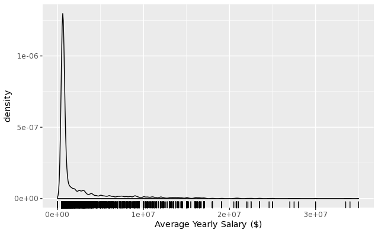

```r
NFL_Salaries %>%
  ggplot(aes(x = avg_year)) + geom_density() + geom_rug() + xlab("Average Yearly Salary ($)")
```

The above graph shows that a very large amount of the players receive a very small average yearly salary in comparison to the fewer amount of players who are paid much larger amounts. I knew there was a drastic difference between the highest salaries and the lowest, but this graph really surprises me with how well it puts the idea into perspective. Only the very best can make it all the way to the top.

### Become Acquainted with Data Source

This is a data source from ESPN, containing 50 cases of NFL quarterback statistics in the most recent regular season (2019). This data tells more of a story about how well the players performed in the most recent season, and I will use this data to compare with their salaries and see if the players matched up to their pay grade. I will mainly use the touchdowns, total yards, average yards per game, QBR, and rating variables for their positive performances, but it may be important to take the interception variable into account as well.

```r
library("rvest")
```

```r
url <- "https://www.espn.com/nfl/stats/player/_/table/passing/sort/passingYards/dir/desc"
PlayerStats <- url %>%
  read_html(header = TRUE) %>%
  html_nodes(css = "table") %>%
  html_table(fill = TRUE)
PlayerStats[[1]]
```

| RK | Name |
| --- | --- |
| 1 | Jameis WinstonTB |
| 2 | Dak PrescottDAL |
| 3 | Jared GoffLAR |
| 4 | Philip RiversLAC |
| 5 | Matt RyanATL |
| 6 | Russell WilsonSEA |
| 7 | Tom BradyNE |
| 8 | Derek CarrOAK |
| 9 | Carson WentzPHI |
| 10 | Patrick MahomesKC |

[output cut: 40 more lines]

```r
PlayerStats[[2]]
```

| POS | GP | CMP | ATT | CMP% | YDS | AVG | YDS/G | LNG | TD | INT | SACK | SYL | QBR | RTG |
| --- | --- | --- | --- | --- | --- | --- | --- | --- | --- | --- | --- | --- | --- | --- |
| QB | 16 | 380 | 626 | 60.7 | 5,109 | 8.2 | 319.3 | 71 | 33 | 30 | 47 | 282 | 53.7 | 84.3 |
| QB | 16 | 388 | 596 | 65.1 | 4,902 | 8.2 | 306.4 | 62 | 30 | 11 | 23 | 151 | 70.2 | 99.7 |
| QB | 16 | 394 | 626 | 62.9 | 4,638 | 7.4 | 289.9 | 66 | 22 | 16 | 22 | 170 | 48.5 | 86.5 |
| QB | 16 | 390 | 591 | 66.0 | 4,615 | 7.8 | 288.4 | 84 | 23 | 20 | 34 | 222 | 48.6 | 88.5 |
| QB | 15 | 408 | 616 | 66.2 | 4,466 | 7.3 | 297.7 | 93 | 26 | 14 | 48 | 316 | 57.6 | 92.1 |
| QB | 16 | 341 | 516 | 66.1 | 4,110 | 8.0 | 256.9 | 60 | 31 | 5 | 48 | 319 | 69.8 | 106.3 |
| QB | 16 | 373 | 613 | 60.8 | 4,057 | 6.6 | 253.6 | 59 | 24 | 8 | 27 | 185 | 53.7 | 88.0 |
| QB | 16 | 361 | 513 | 70.4 | 4,054 | 7.9 | 253.4 | 75 | 21 | 8 | 29 | 184 | 62.2 | 100.8 |
| QB | 16 | 388 | 607 | 63.9 | 4,039 | 6.7 | 252.4 | 53 | 27 | 7 | 37 | 230 | 60.8 | 93.1 |
| QB | 14 | 319 | 484 | 65.9 | 4,031 | 8.3 | 287.9 | 83 | 26 | 5 | 17 | 127 | 76.3 | 105.3 |

[output cut: 40 more lines]

```r
PassingRaw <- PlayerStats[[2]]
PassingStats <-
  bind_cols(PlayerStats[[1]], PlayerStats[[2]]) %>%
  rename(name = Name, position = POS, games_played = GP, completions = CMP, attempts = ATT, completion_pct = "CMP%", total_yds = YDS, avg_yds = AVG, yds_per_game = "YDS/G", longest = LNG, touchdowns = TD, interceptions = INT, sacks_taken = SACK, sack_yds_lost = SYL, QBR = QBR, rating = RTG)
PassingStats
```

| RK | name | position | games_played | completions | attempts | completion_pct | total_yds | avg_yds | yds_per_game | longest | touchdowns | interceptions | sacks_taken | sack_yds_lost | QBR | rating |
| --- | --- | --- | --- | --- | --- | --- | --- | --- | --- | --- | --- | --- | --- | --- | --- | --- |
| 1 | Jameis WinstonTB | QB | 16 | 380 | 626 | 60.7 | 5,109 | 8.2 | 319.3 | 71 | 33 | 30 | 47 | 282 | 53.7 | 84.3 |
| 2 | Dak PrescottDAL | QB | 16 | 388 | 596 | 65.1 | 4,902 | 8.2 | 306.4 | 62 | 30 | 11 | 23 | 151 | 70.2 | 99.7 |
| 3 | Jared GoffLAR | QB | 16 | 394 | 626 | 62.9 | 4,638 | 7.4 | 289.9 | 66 | 22 | 16 | 22 | 170 | 48.5 | 86.5 |
| 4 | Philip RiversLAC | QB | 16 | 390 | 591 | 66.0 | 4,615 | 7.8 | 288.4 | 84 | 23 | 20 | 34 | 222 | 48.6 | 88.5 |
| 5 | Matt RyanATL | QB | 15 | 408 | 616 | 66.2 | 4,466 | 7.3 | 297.7 | 93 | 26 | 14 | 48 | 316 | 57.6 | 92.1 |
| 6 | Russell WilsonSEA | QB | 16 | 341 | 516 | 66.1 | 4,110 | 8.0 | 256.9 | 60 | 31 | 5 | 48 | 319 | 69.8 | 106.3 |
| 7 | Tom BradyNE | QB | 16 | 373 | 613 | 60.8 | 4,057 | 6.6 | 253.6 | 59 | 24 | 8 | 27 | 185 | 53.7 | 88.0 |
| 8 | Derek CarrOAK | QB | 16 | 361 | 513 | 70.4 | 4,054 | 7.9 | 253.4 | 75 | 21 | 8 | 29 | 184 | 62.2 | 100.8 |
| 9 | Carson WentzPHI | QB | 16 | 388 | 607 | 63.9 | 4,039 | 6.7 | 252.4 | 53 | 27 | 7 | 37 | 230 | 60.8 | 93.1 |
| 10 | Patrick MahomesKC | QB | 14 | 319 | 484 | 65.9 | 4,031 | 8.3 | 287.9 | 83 | 26 | 5 | 17 | 127 | 76.3 | 105.3 |

[output cut: 40 more lines]

```r
PassingStats$total_yds <- as.numeric(gsub('[,]', '', PassingStats$total_yds))
PassingStats
```

| RK | name | position | games_played | completions | attempts | completion_pct | total_yds | avg_yds | yds_per_game | longest | touchdowns | interceptions | sacks_taken | sack_yds_lost | QBR | rating |
| --- | --- | --- | --- | --- | --- | --- | --- | --- | --- | --- | --- | --- | --- | --- | --- | --- |
| 1 | Jameis WinstonTB | QB | 16 | 380 | 626 | 60.7 | 5109 | 8.2 | 319.3 | 71 | 33 | 30 | 47 | 282 | 53.7 | 84.3 |
| 2 | Dak PrescottDAL | QB | 16 | 388 | 596 | 65.1 | 4902 | 8.2 | 306.4 | 62 | 30 | 11 | 23 | 151 | 70.2 | 99.7 |
| 3 | Jared GoffLAR | QB | 16 | 394 | 626 | 62.9 | 4638 | 7.4 | 289.9 | 66 | 22 | 16 | 22 | 170 | 48.5 | 86.5 |
| 4 | Philip RiversLAC | QB | 16 | 390 | 591 | 66.0 | 4615 | 7.8 | 288.4 | 84 | 23 | 20 | 34 | 222 | 48.6 | 88.5 |
| 5 | Matt RyanATL | QB | 15 | 408 | 616 | 66.2 | 4466 | 7.3 | 297.7 | 93 | 26 | 14 | 48 | 316 | 57.6 | 92.1 |
| 6 | Russell WilsonSEA | QB | 16 | 341 | 516 | 66.1 | 4110 | 8.0 | 256.9 | 60 | 31 | 5 | 48 | 319 | 69.8 | 106.3 |
| 7 | Tom BradyNE | QB | 16 | 373 | 613 | 60.8 | 4057 | 6.6 | 253.6 | 59 | 24 | 8 | 27 | 185 | 53.7 | 88.0 |
| 8 | Derek CarrOAK | QB | 16 | 361 | 513 | 70.4 | 4054 | 7.9 | 253.4 | 75 | 21 | 8 | 29 | 184 | 62.2 | 100.8 |
| 9 | Carson WentzPHI | QB | 16 | 388 | 607 | 63.9 | 4039 | 6.7 | 252.4 | 53 | 27 | 7 | 37 | 230 | 60.8 | 93.1 |
| 10 | Patrick MahomesKC | QB | 14 | 319 | 484 | 65.9 | 4031 | 8.3 | 287.9 | 83 | 26 | 5 | 17 | 127 | 76.3 | 105.3 |

[output cut: 40 more lines]

```r
head(PassingStats)
```

|  | RK | name | position | games_played | completions | attempts | completion_pct | total_yds | avg_yds | yds_per_game | longest | touchdowns | interceptions | sacks_taken | sack_yds_lost | QBR | rating |
| --- | --- | --- | --- | --- | --- | --- | --- | --- | --- | --- | --- | --- | --- | --- | --- | --- | --- |
| 1 | 1 | Jameis WinstonTB | QB | 16 | 380 | 626 | 60.7 | 5109 | 8.2 | 319.3 | 71 | 33 | 30 | 47 | 282 | 53.7 | 84.3 |
| 2 | 2 | Dak PrescottDAL | QB | 16 | 388 | 596 | 65.1 | 4902 | 8.2 | 306.4 | 62 | 30 | 11 | 23 | 151 | 70.2 | 99.7 |
| 3 | 3 | Jared GoffLAR | QB | 16 | 394 | 626 | 62.9 | 4638 | 7.4 | 289.9 | 66 | 22 | 16 | 22 | 170 | 48.5 | 86.5 |
| 4 | 4 | Philip RiversLAC | QB | 16 | 390 | 591 | 66.0 | 4615 | 7.8 | 288.4 | 84 | 23 | 20 | 34 | 222 | 48.6 | 88.5 |
| 5 | 5 | Matt RyanATL | QB | 15 | 408 | 616 | 66.2 | 4466 | 7.3 | 297.7 | 93 | 26 | 14 | 48 | 316 | 57.6 | 92.1 |
| 6 | 6 | Russell WilsonSEA | QB | 16 | 341 | 516 | 66.1 | 4110 | 8.0 | 256.9 | 60 | 31 | 5 | 48 | 319 | 69.8 | 106.3 |

```r
dim(PassingStats)
```

```
[1] 50 17
```

```r
tail(PassingStats)
```

|  | RK | name | position | games_played | completions | attempts | completion_pct | total_yds | avg_yds | yds_per_game | longest | touchdowns | interceptions | sacks_taken | sack_yds_lost | QBR | rating |
| --- | --- | --- | --- | --- | --- | --- | --- | --- | --- | --- | --- | --- | --- | --- | --- | --- | --- |
| 45 | 45 | Josh RosenMIA | QB | 6 | 58 | 109 | 53.2 | 567 | 5.2 | 94.5 | 40 | 1 | 5 | 16 | 93 | 18.4 | 52.0 |
| 46 | 46 | Brandon AllenDEN | QB | 3 | 39 | 84 | 46.4 | 515 | 6.1 | 171.7 | 75 | 3 | 2 | 9 | 59 | 38.1 | 68.3 |
| 47 | 47 | Ryan FinleyCIN | QB | 3 | 41 | 87 | 47.1 | 474 | 5.4 | 158.0 | 47 | 2 | 2 | 11 | 93 | 23.5 | 62.1 |
| 48 | 48 | Chase DanielCHI | QB | 3 | 45 | 64 | 70.3 | 435 | 6.8 | 145.0 | 37 | 3 | 2 | 7 | 48 | 57.6 | 91.6 |
| 49 | 49 | Luke FalkNYJ | QB | 3 | 47 | 73 | 64.4 | 416 | 5.7 | 138.7 | 36 | 0 | 3 | 16 | 96 | 8.9 | 62.4 |
| 50 | 49 | Brian HoyerIND | QB | 4 | 35 | 65 | 53.8 | 372 | 5.7 | 93.0 | 23 | 4 | 4 | 5 | 47 | 16.3 | 65.7 |

```r
glimpse(PassingStats)
```

[output not shown]

```r
str(PassingStats)
```

```
'data.frame':   50 obs. of  17 variables:
 $ RK            : int  1 2 3 4 5 6 7 8 9 10 ...
 $ name          : chr  "Jameis WinstonTB" "Dak PrescottDAL" "Jared GoffLAR" "Philip RiversLAC" ...
 $ position      : chr  "QB" "QB" "QB" "QB" ...
 $ games_played  : int  16 16 16 16 15 16 16 16 16 14 ...
 $ completions   : int  380 388 394 390 408 341 373 361 388 319 ...
 $ attempts      : int  626 596 626 591 616 516 613 513 607 484 ...
 $ completion_pct: num  60.7 65.1 62.9 66 66.2 66.1 60.8 70.4 63.9 65.9 ...
 $ total_yds     : num  5109 4902 4638 4615 4466 ...
 $ avg_yds       : num  8.2 8.2 7.4 7.8 7.3 8 6.6 7.9 6.7 8.3 ...
 $ yds_per_game  : num  319 306 290 288 298 ...
 $ longest       : int  71 62 66 84 93 60 59 75 53 83 ...
 $ touchdowns    : int  33 30 22 23 26 31 24 21 27 26 ...
 $ interceptions : int  30 11 16 20 14 5 8 8 7 5 ...
 $ sacks_taken   : int  47 23 22 34 48 48 27 29 37 17 ...
 $ sack_yds_lost : int  282 151 170 222 316 319 185 184 230 127 ...
 $ QBR           : num  53.7 70.2 48.5 48.6 57.6 69.8 53.7 62.2 60.8 76.3 ...
 $ rating        : num  84.3 99.7 86.5 88.5 92.1 ...
```

### Explore Intuition Related to Guiding Question

```r
favstats(~ touchdowns, data = PassingStats)
```

|  | min | Q1 | median | Q3 | max | mean | sd | n | missing |
| --- | --- | --- | --- | --- | --- | --- | --- | --- | --- |
|  | 0 | 5.25 | 18.5 | 24 | 36 | 15.76 | 10.3106 | 50 | 0 |

```r
favstats(~ total_yds, data = PassingStats)
```

|  | min | Q1 | median | Q3 | max | mean | sd | n | missing |
| --- | --- | --- | --- | --- | --- | --- | --- | --- | --- |
|  | 372 | 1025.5 | 3001.5 | 3845.75 | 5109 | 2531.08 | 1501.429 | 50 | 0 |

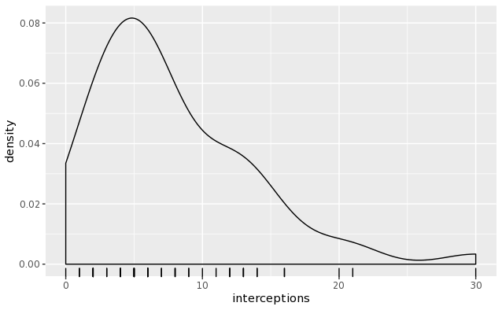

```r
PassingStats %>%
  ggplot(aes(x = interceptions)) + geom_density() + geom_rug()
```

The above graph shows a fairly spread out depiction of the number of interceptions thrown over the year. The density plot shows that the most frequent amount of interceptions thrown for the year was less than 10, but this accounts for injuries and quarterbacks getting benched over the course of the year as well. With 32 NFL teams and 50 quarterbacks in the data set, this density plot was bound to be pushed to the left at least slightly.

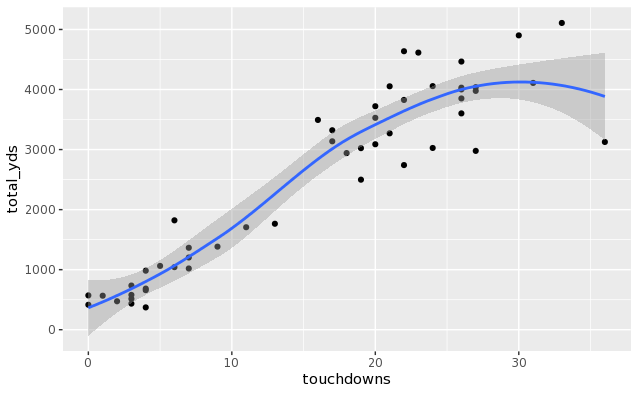

```r
PassingStats %>%
  ggplot(aes(x = touchdowns, y = total_yds)) + geom_point() + geom_smooth()
```

The above graph shows me that the total yards and number of touchdowns for quarterbacks in the 2019 NFL season have a fairly strong positive correlation. However, this relationship isn’t exactly linear, as it tails off at the higher end. This could happen for multiple reasons, but my preliminary guess would be that the number of touchdowns has more variability than the number of yards thrown for in a season. This is shown by the smoother, as the confidence band gets significantly wider at the higher end of the data. This makes sense because yards should accumulate over the season to the typical average for the player, while touchdown numbers could fluctuate per season depending on other factors such as percent of time in the redzone and etc.

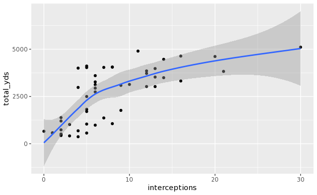

```r
PassingStats %>%
  ggplot(aes(x = interceptions, y = total_yds)) + geom_point() + geom_smooth()
```

```r
PassingStats %>%
  filter(interceptions > 29)
```

| RK | name | position | games_played | completions | attempts | completion_pct | total_yds | avg_yds | yds_per_game | longest | touchdowns | interceptions | sacks_taken | sack_yds_lost | QBR | rating |
| --- | --- | --- | --- | --- | --- | --- | --- | --- | --- | --- | --- | --- | --- | --- | --- | --- |
| 1 | Jameis WinstonTB | QB | 16 | 380 | 626 | 60.7 | 5109 | 8.2 | 319.3 | 71 | 33 | 30 | 47 | 282 | 53.7 | 84.3 |

After following this past NFL season fairly closely, I know that this number of interceptions is legitimate. For this reason, I will not remove the possible outlier.

### Using both Data Sources

The first thing I have noticed that may become a problem is the fact that the “name” variable for the two data sets contain different information. In the NFL_Salaries data table, the name is just the first and last name of the player. However, the name column in the PlayerStats data table contains their first and last name and their team’s abbreviation. Before joining these two tables, I need to figure out how to split the team abbreviation from the name and create a separate variable for the team abbreviation. This would allow me to then join the two tables by the player names I am looking for.

### Joining the two tables

```r
PassingStats <- PassingStats %>%
  tidyr::extract(col = name, into = "team", regex = "([QWERTYUIOPASDFGHJKLZXCVBNM][QWERTYUIOPASDFGHJKLZXCVBNM].$|[QWERTYUIOPASDFGHJKLZXCVBNM][QWERTYUIOPASDFGHJKLZXCVBNM]$)", remove = FALSE)
PassingStats
```

| RK | name | team | position | games_played | completions | attempts | completion_pct | total_yds | avg_yds | yds_per_game | longest | touchdowns | interceptions | sacks_taken | sack_yds_lost | QBR | rating |
| --- | --- | --- | --- | --- | --- | --- | --- | --- | --- | --- | --- | --- | --- | --- | --- | --- | --- |
| 1 | Jameis WinstonTB | TB | QB | 16 | 380 | 626 | 60.7 | 5109 | 8.2 | 319.3 | 71 | 33 | 30 | 47 | 282 | 53.7 | 84.3 |
| 2 | Dak PrescottDAL | DAL | QB | 16 | 388 | 596 | 65.1 | 4902 | 8.2 | 306.4 | 62 | 30 | 11 | 23 | 151 | 70.2 | 99.7 |
| 3 | Jared GoffLAR | LAR | QB | 16 | 394 | 626 | 62.9 | 4638 | 7.4 | 289.9 | 66 | 22 | 16 | 22 | 170 | 48.5 | 86.5 |
| 4 | Philip RiversLAC | LAC | QB | 16 | 390 | 591 | 66.0 | 4615 | 7.8 | 288.4 | 84 | 23 | 20 | 34 | 222 | 48.6 | 88.5 |
| 5 | Matt RyanATL | ATL | QB | 15 | 408 | 616 | 66.2 | 4466 | 7.3 | 297.7 | 93 | 26 | 14 | 48 | 316 | 57.6 | 92.1 |
| 6 | Russell WilsonSEA | SEA | QB | 16 | 341 | 516 | 66.1 | 4110 | 8.0 | 256.9 | 60 | 31 | 5 | 48 | 319 | 69.8 | 106.3 |
| 7 | Tom BradyNE | NE | QB | 16 | 373 | 613 | 60.8 | 4057 | 6.6 | 253.6 | 59 | 24 | 8 | 27 | 185 | 53.7 | 88.0 |
| 8 | Derek CarrOAK | OAK | QB | 16 | 361 | 513 | 70.4 | 4054 | 7.9 | 253.4 | 75 | 21 | 8 | 29 | 184 | 62.2 | 100.8 |
| 9 | Carson WentzPHI | PHI | QB | 16 | 388 | 607 | 63.9 | 4039 | 6.7 | 252.4 | 53 | 27 | 7 | 37 | 230 | 60.8 | 93.1 |
| 10 | Patrick MahomesKC | KC | QB | 14 | 319 | 484 | 65.9 | 4031 | 8.3 | 287.9 | 83 | 26 | 5 | 17 | 127 | 76.3 | 105.3 |

[output cut: 40 more lines]

```r
PassingStats <- PassingStats %>%
  tidyr::extract(col = name, into = "player", regex = "([QWERTYUIOPASDFGHJKLZXCVBNM][qwertyuiopasdfghjklzxcvbnm]+ [QWERTYUIOPASDFGHJKLZXCVBNM][qwertyuiopasdfghjklzxcvbnm]+)")
PassingStats
```

| RK | player | team | position | games_played | completions | attempts | completion_pct | total_yds | avg_yds | yds_per_game | longest | touchdowns | interceptions | sacks_taken | sack_yds_lost | QBR | rating |
| --- | --- | --- | --- | --- | --- | --- | --- | --- | --- | --- | --- | --- | --- | --- | --- | --- | --- |
| 1 | Jameis Winston | TB | QB | 16 | 380 | 626 | 60.7 | 5109 | 8.2 | 319.3 | 71 | 33 | 30 | 47 | 282 | 53.7 | 84.3 |
| 2 | Dak Prescott | DAL | QB | 16 | 388 | 596 | 65.1 | 4902 | 8.2 | 306.4 | 62 | 30 | 11 | 23 | 151 | 70.2 | 99.7 |
| 3 | Jared Goff | LAR | QB | 16 | 394 | 626 | 62.9 | 4638 | 7.4 | 289.9 | 66 | 22 | 16 | 22 | 170 | 48.5 | 86.5 |
| 4 | Philip Rivers | LAC | QB | 16 | 390 | 591 | 66.0 | 4615 | 7.8 | 288.4 | 84 | 23 | 20 | 34 | 222 | 48.6 | 88.5 |
| 5 | Matt Ryan | ATL | QB | 15 | 408 | 616 | 66.2 | 4466 | 7.3 | 297.7 | 93 | 26 | 14 | 48 | 316 | 57.6 | 92.1 |
| 6 | Russell Wilson | SEA | QB | 16 | 341 | 516 | 66.1 | 4110 | 8.0 | 256.9 | 60 | 31 | 5 | 48 | 319 | 69.8 | 106.3 |
| 7 | Tom Brady | NE | QB | 16 | 373 | 613 | 60.8 | 4057 | 6.6 | 253.6 | 59 | 24 | 8 | 27 | 185 | 53.7 | 88.0 |
| 8 | Derek Carr | OAK | QB | 16 | 361 | 513 | 70.4 | 4054 | 7.9 | 253.4 | 75 | 21 | 8 | 29 | 184 | 62.2 | 100.8 |
| 9 | Carson Wentz | PHI | QB | 16 | 388 | 607 | 63.9 | 4039 | 6.7 | 252.4 | 53 | 27 | 7 | 37 | 230 | 60.8 | 93.1 |
| 10 | Patrick Mahomes | KC | QB | 14 | 319 | 484 | 65.9 | 4031 | 8.3 | 287.9 | 83 | 26 | 5 | 17 | 127 | 76.3 | 105.3 |

[output cut: 40 more lines]

```r
PassingStats$player[29] = "Matt Stafford"
PassingStats$player
```

```
 [1] "Jameis Winston"    "Dak Prescott"      "Jared Goff"
 [4] "Philip Rivers"     "Matt Ryan"         "Russell Wilson"
 [7] "Tom Brady"         "Derek Carr"        "Carson Wentz"
[10] "Patrick Mahomes"   "Aaron Rodgers"     "Jimmy Garoppolo"
[13] "Deshaun Watson"    "Baker Mayfield"    "Kyler Murray"
[16] "Kirk Cousins"      "Ryan Fitzpatrick"  "Andy Dalton"
[19] "Kyle Allen"        "Gardner Minshew"   "Mitchell Trubisky"
[22] "Lamar Jackson"     "Josh Allen"        "Daniel Jones"
[25] "Sam Darnold"       "Drew Brees"        "Jacoby Brissett"
[28] "Ryan Tannehill"    "Matt Stafford"     "Joe Flacco"
[31] "Mason Rudolph"     "Case Keenum"       "Teddy Bridgewater"
[34] "Dwayne Haskins"    "Marcus Mariota"    "Devlin Hodges"
[37] "Eli Manning"       "Drew Lock"         "David Blough"
[40] "Nick Foles"        "Jeff Driskel"      "Matt Moore"
[43] "Matt Schaub"       "Cam Newton"        "Josh Rosen"
[46] "Brandon Allen"     "Ryan Finley"       "Chase Daniel"
[49] "Luke Falk"         "Brian Hoyer"
```

```r
Complete_Table <- PassingStats %>%
  left_join(NFL_Salaries, by = c("player" = "player")) %>%
  filter(position.y == "quarterback")
```

```
Column `player` joining character vector and factor, coercing into character vector
```

```r
Complete_Table
```

| RK | player | team.x | position.x | games_played | completions | attempts | completion_pct | total_yds | avg_yds | yds_per_game | longest | touchdowns | interceptions | sacks_taken | sack_yds_lost | QBR | rating | position.y | team.y | age | total_value | avg_year | total_guaranteed | fully_guaranteed | free_agency |
| --- | --- | --- | --- | --- | --- | --- | --- | --- | --- | --- | --- | --- | --- | --- | --- | --- | --- | --- | --- | --- | --- | --- | --- | --- | --- |
| 1 | Jameis Winston | TB | QB | 16 | 380 | 626 | 60.7 | 5109 | 8.2 | 319.3 | 71 | 33 | 30 | 47 | 282 | 53.7 | 84.3 | quarterback | Buccaneers | 25 | 25351277 | 6337819 | 25351277 | 25351277 | 2020 UFA |
| 2 | Dak Prescott | DAL | QB | 16 | 388 | 596 | 65.1 | 4902 | 8.2 | 306.4 | 62 | 30 | 11 | 23 | 151 | 70.2 | 99.7 | quarterback | Cowboys | 26 | 2723392 | 680848 | 383392 | 383392 | 2020 UFA |
| 3 | Jared Goff | LAR | QB | 16 | 394 | 626 | 62.9 | 4638 | 7.4 | 289.9 | 66 | 22 | 16 | 22 | 170 | 48.5 | 86.5 | quarterback | Rams | 25 | 27937672 | 6984418 | 27937672 | 27937672 | 2021 UFA |
| 4 | Philip Rivers | LAC | QB | 16 | 390 | 591 | 66.0 | 4615 | 7.8 | 288.4 | 84 | 23 | 20 | 34 | 222 | 48.6 | 88.5 | quarterback | Chargers | 38 | 83250000 | 20812500 | 65000000 | 37500000 | 2020 UFA |
| 5 | Matt Ryan | ATL | QB | 15 | 408 | 616 | 66.2 | 4466 | 7.3 | 297.7 | 93 | 26 | 14 | 48 | 316 | 57.6 | 92.1 | quarterback | Falcons | 34 | 150000000 | 30000000 | 100000000 | 94500000 | 2024 UFA |
| 6 | Russell Wilson | SEA | QB | 16 | 341 | 516 | 66.1 | 4110 | 8.0 | 256.9 | 60 | 31 | 5 | 48 | 319 | 69.8 | 106.3 | quarterback | Seahawks | 31 | 140000000 | 35000000 | 107000000 | 70000000 | 2024 UFA |
| 7 | Tom Brady | NE | QB | 16 | 373 | 613 | 60.8 | 4057 | 6.6 | 253.6 | 59 | 24 | 8 | 27 | 185 | 53.7 | 88.0 | quarterback | Patriots | 42 | 41000000 | 20500000 | 30000000 | 28000000 | 2020 UFA |
| 8 | Derek Carr | OAK | QB | 16 | 361 | 513 | 70.4 | 4054 | 7.9 | 253.4 | 75 | 21 | 8 | 29 | 184 | 62.2 | 100.8 | quarterback | Raiders | 28 | 125025000 | 25005000 | 70200000 | 40000000 | 2023 UFA |
| 9 | Carson Wentz | PHI | QB | 16 | 388 | 607 | 63.9 | 4039 | 6.7 | 252.4 | 53 | 27 | 7 | 37 | 230 | 60.8 | 93.1 | quarterback | Eagles | 27 | 26676338 | 6669085 | 26676338 | 26676338 | 2021 UFA |
| 10 | Patrick Mahomes | KC | QB | 14 | 319 | 484 | 65.9 | 4031 | 8.3 | 287.9 | 83 | 26 | 5 | 17 | 127 | 76.3 | 105.3 | quarterback | Chiefs | 24 | 16425962 | 4106491 | 16425962 | 16425962 | 2021 UFA |

[output cut: 39 more lines]

Note that Matt Moore was dropped from the data set once the tables were joined, due to the fact that he did not have any data in the NFL_Salaries data table. This makes sense because he recently came out of retirement to join the Kansas City Cheifs. He wasn’t the main starter this season for the Chiefs anyways, so this is okay.

### Further Data Analysis

```r
Grouped_Complete_Table <- Complete_Table %>%
  group_by(team.x) %>%
  summarise(total_tds = sum(touchdowns), total_ints = sum(interceptions), avg_salary = mean(avg_year), total_yards = sum(total_yds))
Grouped_Complete_Table
```

| team.x | total_tds | total_ints | avg_salary | total_yards |
| --- | --- | --- | --- | --- |
| ARI | 20 | 12 | 8789661.0 | 3722 |
| ATL | 29 | 15 | 15945000.0 | 5046 |
| BAL | 36 | 6 | 2367913.0 | 3127 |
| BUF | 20 | 9 | 5295759.0 | 3089 |
| CAR | 17 | 17 | 10623750.0 | 3894 |
| CHI | 20 | 12 | 6129054.5 | 3573 |
| CIN | 18 | 16 | 8413707.5 | 3968 |
| CLE | 22 | 21 | 8170745.0 | 3827 |
| DAL | 30 | 11 | 680848.0 | 4902 |
| DEN | 16 | 10 | 8177012.7 | 3357 |

[output cut: 22 more lines]

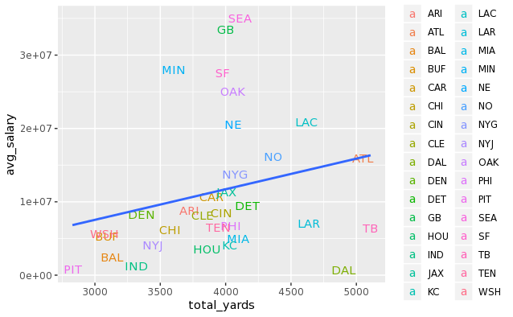

```r
Grouped_Complete_Table %>%
  ggplot(aes(x = total_yards, y = avg_salary)) +  geom_text(aes(label = team.x, color = team.x)) + geom_smooth(method = lm, se = FALSE)
```

The above graph shows a 3-variable scatterplot in which the x-axis has the total yards, the y-axis has the average salary, and the points are labeled and colored by the team name. The quarterbacks are grouped by team, so all 32 teams are respresented, but the data may contain the total information for two or more quarterbacks (due to injuries, benchings, etc.). I then added a line of best fit to show whether teams seemed to be overpaying or underpaying their quarterbacks based on the average for their performance level (total yards in the season). As you can see, teams like GB and SEA seem to have paid much more for their quarterbacks at a similar amount of total yards, but those two teams did in fact make the playoffs this past season. On the other hand, teams like TB and DAL seem to have paid very little for their quarterbacks that provided a much higher amount of total yards, but these two teams missed the playoffs this past season. This shows that yardage numbers are not the only factor that goes into good quarterback play; the quarterback must also elevate the team around him because football is a team sport.

```r
Rich_Quarterback <- lm(avg_year >= 20000000 ~ age + QBR + completion_pct + touchdowns + interceptions, data = Complete_Table)
summary(Rich_Quarterback)
```

```
Call:
lm(formula = avg_year >= 2e+07 ~ age + QBR + completion_pct +
    touchdowns + interceptions, data = Complete_Table)

Residuals:
     Min       1Q   Median       3Q      Max
-0.54648 -0.33028 -0.08985  0.34156  0.67280

Coefficients:
                Estimate Std. Error t value Pr(>|t|)
(Intercept)    -1.047059   0.725216  -1.444  0.15604
age             0.018907   0.005934   3.186  0.00269 **
QBR            -0.009554   0.006159  -1.551  0.12819
completion_pct  0.018428   0.013735   1.342  0.18674
touchdowns      0.019546   0.010256   1.906  0.06339 .
interceptions  -0.020628   0.012798  -1.612  0.11433
---
Signif. codes:  0 ‘***’ 0.001 ‘**’ 0.01 ‘*’ 0.05 ‘.’ 0.1 ‘ ’ 1

Residual standard error: 0.3973 on 43 degrees of freedom
Multiple R-squared:  0.3214,    Adjusted R-squared:  0.2425
F-statistic: 4.073 on 5 and 43 DF,  p-value: 0.004092
```

Here I am using machine learning to create a linear model. This model tells me that the age variable is significant at the 5% significance level, and the touchdowns variable is significant at the 10% significance level in predicting if a quarterback’s yearly salary is over $20,000,000. The age variable definitely makes sense, because young quarterbacks who were recently drafted are not qualified to be paid large amounts of money until they spend at least 4 years in the league. I am a little surprised that QBR isn’t significant because that is the newest rating system in which quarterback play is graded (on a 100 point scale), so clearly the new method still isn’t perfect. Of the quantitative variables (that have to do with performance, so not including age) selected for the model, touchdowns seem to be the best predictor of the bunch in order to predict average yearly salary for quarterbacks in the NFL today. However, this was still not significant at the 5% level, so we are not as certain as we would like that this variable is a great predictor.

This anaylysis is interesting to complete because many different factors go into the decision-making processes for General Managers (GMs) in the NFL when decide how much or who to pay. By sorting through all of this data, it really makes you gain a lot of respect for the GMs and how well they are able to do their jobs (for the most part). As a huge sports fan, my dream would be to get into the industry with my knowledge of statistics and data analyzation to go along with my knowledge of the game.

The biggest challenge I came across was the problem of the two tables having differnt “names” for the players (one contained the team abbreviation joined with the names). This would have been a huge problem because I needed the names to be the same in order to join the salary data to that player’s statistical data. However, the reg ex lecture helped me out a lot and once I sat down and grinded out a pattern I finally figured it out. This made the rest of my analysis pretty smooth. I also have a lot of quantitative data, so I tried hard to switch up some of my plots so that they all didn’t look like boring scatterplots. My favorite plot is the multi-variable plot which is colored by team name and overlayed with a line of best fit.